# CD8 Stem-like Analysis — Step 2: Subject-level Statistics and Marker Expression

```
CD8 labels used: CD8 T
```

```
Total Monaco-defined CD8 cells: 47,386
```

# 1. Statistical analysis of the five-transcript CD8 population

This analysis tests whether the proportion of Monaco-defined CD8 cells with simultaneous detection of **TCF7, SLAMF6, CD28, CCR7, and SELL RNA** differs between untrained cells and each of the three pre-PMA training conditions (SYKi, MDP, BG).

Pre-PMA five-transcript CD8 population by subject

| sCALL | LaneGroup | Total_CD8 | Five_marker_cells | Percent_CD8 |
| --- | --- | --- | --- | --- |
| P205235 | untrained | 2121 | 95 | 4.48 |
| P205235 | SYKi | 2099 | 139 | 6.62 |
| P205235 | MDP | 2056 | 114 | 5.54 |
| P205235 | BG | 2164 | 127 | 5.87 |
| P213102 | untrained | 1305 | 21 | 1.61 |
| P213102 | SYKi | 717 | 19 | 2.65 |
| P213102 | MDP | 796 | 21 | 2.64 |
| P213102 | BG | 898 | 13 | 1.45 |
| P219837 | untrained | 2120 | 131 | 6.18 |
| P219837 | SYKi | 2247 | 184 | 8.19 |
| P219837 | MDP | 2201 | 134 | 6.09 |
| P219837 | BG | 2044 | 75 | 3.67 |
| P228725 | untrained | 2434 | 143 | 5.88 |
| P228725 | SYKi | 2486 | 198 | 7.96 |
| P228725 | MDP | 2057 | 133 | 6.47 |
| P228725 | BG | 2120 | 115 | 5.42 |
| P230831 | untrained | 1164 | 92 | 7.90 |
| P230831 | SYKi | 1240 | 89 | 7.18 |
| P230831 | MDP | 1237 | 92 | 7.44 |
| P230831 | BG | 1095 | 52 | 4.75 |

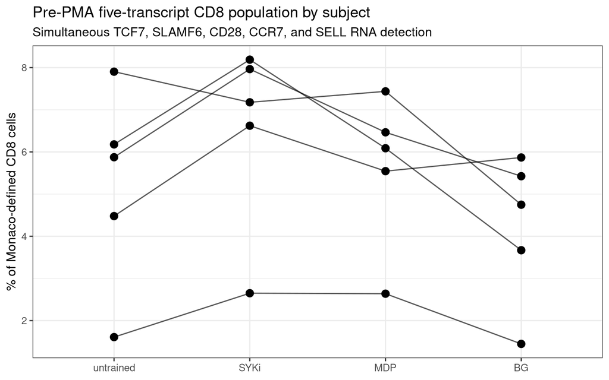

# 2. Overall pre-PMA comparison

```
Subjects with complete data for all four conditions: 5
```

```
Overall Friedman test across the four pre-PMA conditions: p = 0.06237
```

## Paired comparisons versus untrained

Five-transcript CD8 percentage with panel-specific correction

| Condition | N_subjects | Mean_diff_pct_points | N_increased | Wilcoxon_p | Limma_p | Panel_adj.P.Val |
| --- | --- | --- | --- | --- | --- | --- |
| SYKi | 5 | 1.311 | 4 | 0.1056 | 0.0750 | 0.2250 |
| MDP | 5 | 0.426 | 3 | 0.2807 | 0.2358 | 0.3021 |
| BG | 5 | -0.977 | 1 | 0.2807 | 0.3021 | 0.3021 |

```
Number of pseudobulk samples: 20
```

```
Design matrix dimensions: 20 x 8
```

Targeted analysis of six prespecified stem-like CD8 marker genes. Nominal p-values are reported.

| Gene | Comparison | logFC | AveExpr | P.Value |
| --- | --- | --- | --- | --- |
| TCF7 | SYKi vs untrained | 0.090 | 8.208 | 0.0358 |
| PDCD1 | SYKi vs untrained | -0.455 | 1.041 | 0.0607 |
| SLAMF6 | SYKi vs untrained | 0.027 | 6.494 | 0.6916 |
| CD28 | SYKi vs untrained | 0.090 | 6.796 | 0.1717 |
| CCR7 | SYKi vs untrained | -0.051 | 7.117 | 0.1871 |
| SELL | SYKi vs untrained | 0.143 | 7.241 | 0.0190 |
| TCF7 | MDP vs untrained | 0.061 | 8.208 | 0.1422 |
| PDCD1 | MDP vs untrained | -0.525 | 1.041 | 0.0334 |
| SLAMF6 | MDP vs untrained | -0.062 | 6.494 | 0.3667 |
| CD28 | MDP vs untrained | -0.043 | 6.796 | 0.5174 |
| CCR7 | MDP vs untrained | 0.146 | 7.117 | 0.0008 |
| SELL | MDP vs untrained | 0.083 | 7.241 | 0.1550 |
| TCF7 | BG vs untrained | 0.041 | 8.208 | 0.3229 |
| PDCD1 | BG vs untrained | 0.146 | 1.041 | 0.5077 |
| SLAMF6 | BG vs untrained | 0.091 | 6.494 | 0.1962 |
| CD28 | BG vs untrained | -0.127 | 6.796 | 0.0708 |
| CCR7 | BG vs untrained | -0.023 | 7.117 | 0.5456 |
| SELL | BG vs untrained | -0.068 | 7.241 | 0.2542 |

# 5. Marker-expression plot

Red bars indicate **nominal p < 0.05** for the prespecified targeted genes. Because these genes were selected a priori based on the biological hypothesis, FDR correction is not used as the significance criterion in this targeted analysis.

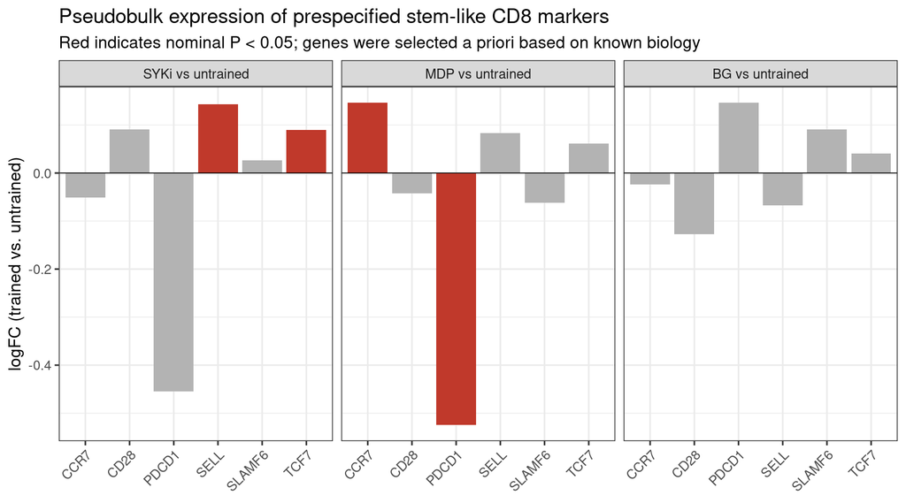

# 6. Individual-subject expression of the six targeted genes

The pseudobulk differential-expression analysis estimates the overall training-associated effect while accounting for subject. The plots below show the underlying expression values for each individual subject. Each line connects samples from the same subject across the four pre-PMA conditions.

This visualization is important for determining whether the direction of a gene-expression difference is consistent across subjects or is primarily driven by an individual subject.

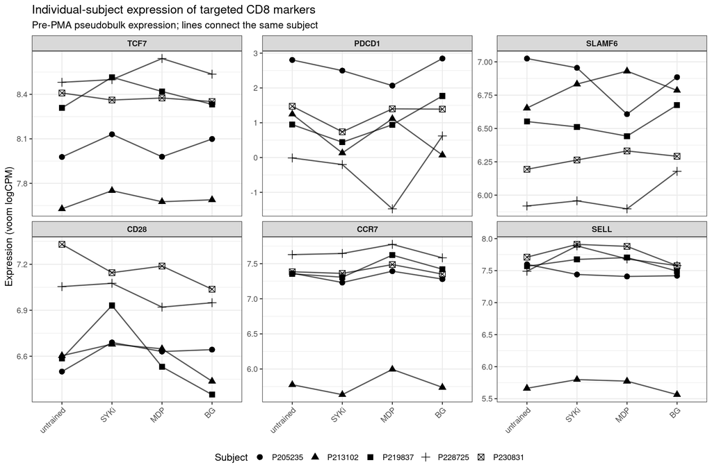

# 7. Summary

At the subject level, SYKi produced the most consistent increase in the RNA-defined stem-like/memory CD8 population, with an increase observed in 4 of 5 subjects and an average increase of 1.31 percentage points compared with untrained. Although this did not reach statistical significance with only five subjects (limma p=0.075; Wilcoxon p=0.106), the consistency and direction of the SYKi response support further investigation. Targeted pseudobulk analysis of the six stem-like CD8-associated genes was also performed to determine whether training is associated with changes in their expression. The six genes evaluated in this analysis (**TCF7, PDCD1, SLAMF6, CD28, CCR7, and SELL**) were prespecified based on their known relevance to the stem-like CD8 T-cell phenotype rather than selected from an exploratory genome-wide analysis.

Accordingly, the targeted pseudobulk analysis reports **nominal p-values** for the individual gene-level hypotheses. A nominal **P < 0.05** is used to highlight results in the figure. The magnitude and direction of the log-fold change and consistency of the response across subjects should be considered together with the p-values.

The five-transcript cell population is separately defined by simultaneous RNA detection of **TCF7, SLAMF6, CD28, CCR7, and SELL** within the same Monaco-defined CD8 cell. Subject-level proportions are used so that individual cells are not treated as independent biological replicates.